title: “First_Forecast_Project” author: “Bibek Kandel” date: “2025-12-27” output: html_document —

```r
options(repos = c(CRAN = "https://cloud.r-project.org"))
```

```r
install.packages('tidymodels')
install.packages('readr') # package for applying simple forecasting methods
install.packages('lubridate') # package for dealing with time series data sets and tsibble objects
install.packages('tidyverse') # collection of R packages for data manipulation, analysis, and visualisation
install.packages('dplyr')# working with dates and times
install.packages('ranger')
install.packages('randomForest')
remotes::install_github('eco4cast/neon4cast', force = T) # package from NEON4cast challenge organisers to assist with forecast building and submission
```

#Initialize the libraries

```r
library(tidymodels)
library(tidyverse)
library(readr)
library(lubridate)
library(dplyr)
library(ranger)
library(randomForest)
tidymodels_prefer()
set.seed(100) #for random number generation
```

#Create historical met dataframe to include lag

```r
noaa_forecast_start <- Sys.Date() - days(2)
min_historical_day <- Sys.Date() - days(60)
variables <- c("air_temperature", "northward_wind", "eastward_wind", "surface_downwelling_shortwave_flux_in_air")
sites <- c("BARC", "SUGG", "CRAM", "LIRO", "TOOK", "PRPO", "PRLA")

noaa_past_mean <-  neon4cast::noaa_stage3() |>
  filter(site_id %in% sites,
                variable %in% variables,
                datetime > min_historical_day,
                datetime < noaa_forecast_start) |>
  collect() |>
  dplyr::mutate(datetime = as_date(datetime)) |>
  dplyr::summarize(prediction = mean(prediction), .by = c("datetime", "site_id", "parameter", "variable")) |>
  pivot_wider(names_from = variable, values_from = prediction) |>
  dplyr::mutate(air_temperature = air_temperature - 273.15)

noaa_future_mean <- neon4cast::noaa_stage2(start_date = noaa_forecast_start) |>
  filter(datetime >= noaa_forecast_start,
                site_id %in% sites,
                variable %in% variables) |>
  collect() |>
  dplyr::mutate(datetime = as_date(datetime)) |>
  dplyr::summarize(prediction = mean(prediction), .by = c("datetime", "site_id", "parameter", "variable")) |>
  pivot_wider(names_from = variable, values_from = prediction) |>
  dplyr::mutate(air_temperature = air_temperature - 273.15) |>
  select(datetime, site_id, air_temperature,northward_wind,eastward_wind,surface_downwelling_shortwave_flux_in_air, parameter)

combined_met_df <- bind_rows(noaa_past_mean, noaa_future_mean)
combined_met_df <- combined_met_df |>
  dplyr::mutate(doy = yday(datetime))
```

#Plot the historical ensemble air temperature data for all sites

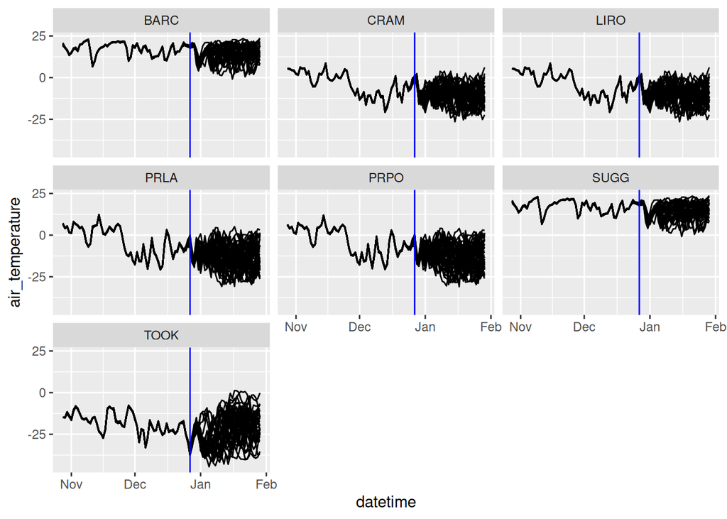

```r
ggplot(combined_met_df, aes(x = datetime, y = air_temperature, group = parameter)) +
  geom_line() +
  geom_vline(aes(xintercept = Sys.Date()), color = "blue")+
  facet_wrap(~site_id)
```

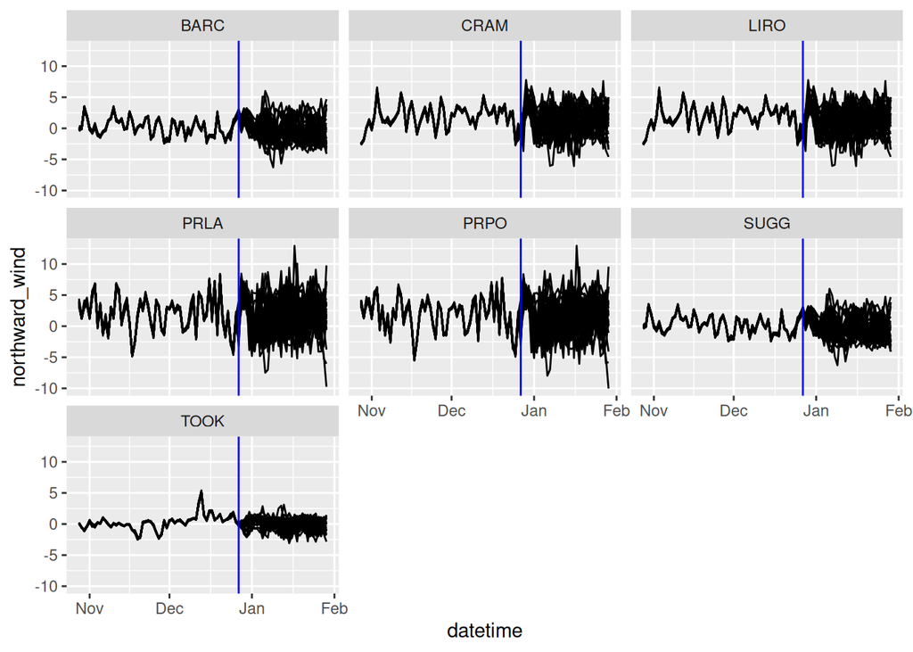

```r
ggplot(combined_met_df, aes(x = datetime, y = northward_wind, group = parameter)) +
  geom_line() +
  geom_vline(aes(xintercept = Sys.Date()), color = "blue")+
  facet_wrap(~site_id)
```

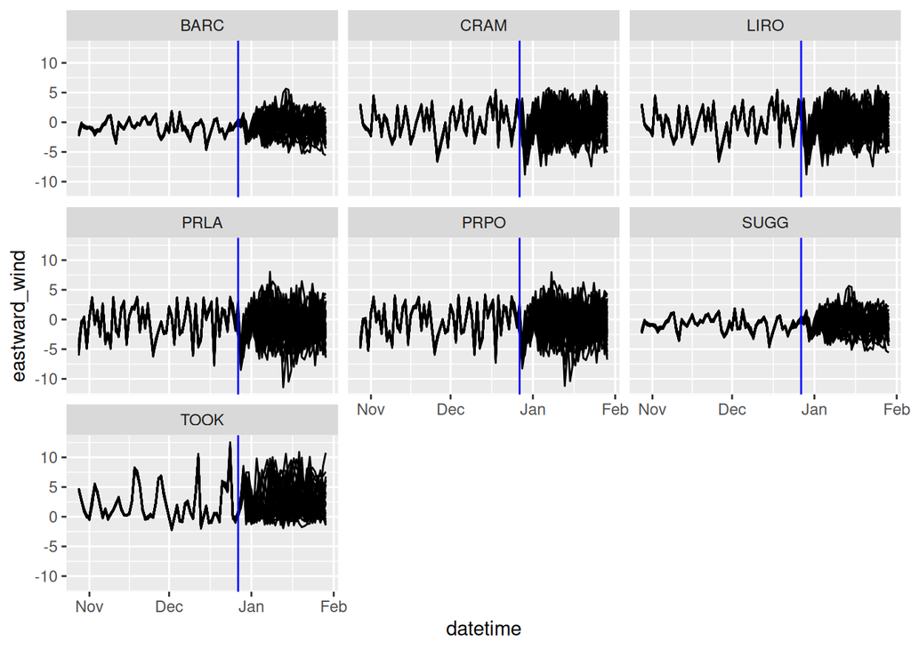

```r
ggplot(combined_met_df, aes(x = datetime, y = eastward_wind, group = parameter)) +
  geom_line() +
  geom_vline(aes(xintercept = Sys.Date()), color = "blue")+
  facet_wrap(~site_id)
```

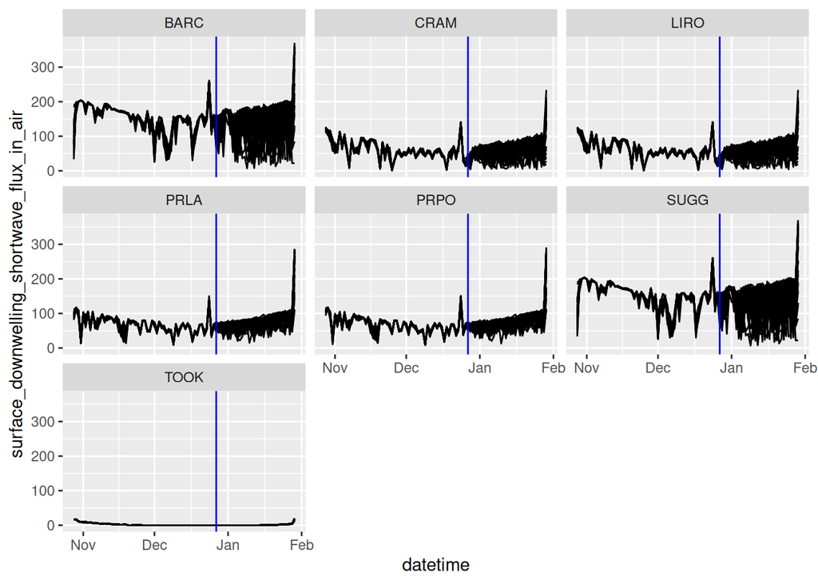

```r
ggplot(combined_met_df, aes(x = datetime, y = surface_downwelling_shortwave_flux_in_air, group = parameter)) +
  geom_line() +
  geom_vline(aes(xintercept = Sys.Date()), color = "blue")+
  facet_wrap(~site_id)
```

#Tidymodels #Step 1: Obtain data

```r
lake_sites <- c("BARC", "SUGG", "CRAM", "LIRO", "TOOK", "PRPO", "PRLA")

targets <- read_csv('https://data.ecoforecast.org/neon4cast-targets/aquatics/aquatics-targets.csv.gz',
                    show_col_types = FALSE) |>
  filter(site_id %in% lake_sites)
```

```r
targets <- targets |>
  filter(site_id %in% lake_sites,
         variable == "temperature")
```

```r
# past stacked weather
df_past <- neon4cast::noaa_stage3()

variables <- c("air_temperature", "northward_wind", "eastward_wind", "surface_downwelling_shortwave_flux_in_air")

noaa_past <- df_past |>
  dplyr::filter(site_id %in% lake_sites,
                datetime >= ymd('2017-01-01'),
                variable %in% variables) |>
  dplyr::collect()
```

```r
# aggregate the past to mean values
noaa_past_mean <- noaa_past |>
  dplyr::mutate(datetime = as_date(datetime)) |>
  group_by(datetime, site_id, variable) |>
  dplyr::summarize(prediction = mean(prediction, na.rm = TRUE), .groups = "drop") |>
  pivot_wider(names_from = variable, values_from = prediction) |>
  # convert air temp to C
  dplyr::mutate(air_temperature = air_temperature - 273.15)
```

```r
#Create a new column with combined windspeed
noaa_past_mean <- noaa_past_mean |>
  mutate(windspeed = sqrt((northward_wind)^2 + (eastward_wind)^2))
```

```r
forecast_date <- Sys.Date()
noaa_date <- forecast_date - lubridate::days(2)

df_future <- neon4cast::noaa_stage2(start_date = noaa_date)

variables <- c("air_temperature", "northward_wind", "eastward_wind", "surface_downwelling_shortwave_flux_in_air")

noaa_future <- df_future |>
  dplyr::filter(reference_datetime == noaa_date,
                datetime >= forecast_date,
                site_id %in% lake_sites,
                variable %in% variables) |>
  dplyr::collect()
```

```r
noaa_future_daily <- noaa_future |>
  dplyr::mutate(datetime = as_date(datetime)) |>
  # mean daily forecasts at each site per ensemble
  dplyr::summarize(prediction = mean(prediction), .by = c("datetime", "site_id", "parameter", "variable")) |>
  pivot_wider(names_from = variable, values_from = prediction) |>
  # convert to Celsius
  dplyr::mutate(air_temperature = air_temperature - 273.15) |>
  select(datetime, site_id, air_temperature, northward_wind, eastward_wind,surface_downwelling_shortwave_flux_in_air, parameter)
```

```r
#Create a new column with combined windspeed
noaa_future_daily <- noaa_future_daily |>
  mutate(windspeed = sqrt((northward_wind)^2 + (eastward_wind)^2))
```

```r
targets_df <- targets |>
  filter(variable == 'temperature') |>
  pivot_wider(names_from = 'variable', values_from = 'observation') |>
  left_join(noaa_past_mean,
            by = c("datetime","site_id")) |>
  dplyr::mutate(doy = yday(datetime))
```

```r
#ddply(targets_df, .(site_id), nrow) #count the no of rows by site
```

#Step 2: Pre-process data

```r
#Split data into training/testing sets
#We are going to split the data into training and testing sets using the initial_split function. prop = 0.80 says to use 80% of the data in the training set.
targets_df <- targets_df %>%
  na.omit()
split <- initial_split(targets_df, prop = 0.80, strata = site_id)
split
```

```
## <Training/Testing/Total>
## <5795/1452/7247>
```

```r
#To actually get the training and testing data we need to apply the training() and testing() functions to the split.

train_data <- training(split)
test_data <- testing(split)
```

```r
#You can see that train_data is a data frame that we can work with.
train_data
```

```
## # A tibble: 5,795 × 9
##    datetime   site_id temperature air_temperature eastward_wind northward_wind
##    <date>     <chr>         <dbl>           <dbl>         <dbl>          <dbl>
##  1 2020-09-24 BARC           27.2            24.7         1.01          -1.46
##  2 2020-09-25 BARC           27.9            27.3         0.843         -0.213
##  3 2020-09-26 BARC           28.7            27.4        -0.632          1.13
##  4 2020-09-27 BARC           28.7            25.8        -0.156         -0.996
##  5 2020-09-28 BARC           28.1            25.2         1.06          -0.496
##  6 2020-09-29 BARC           28.0            24.8         1.56           0.865
##  7 2020-09-30 BARC           27.6            19.1        -2.37           0.617
##  8 2020-10-01 BARC           27.3            20.2        -1.10           0.106
##  9 2020-10-04 BARC           25.7            20.3        -3.06          -0.649
## 10 2020-10-05 BARC           25.2            22.1        -2.67          -1.95
## # ℹ 5,785 more rows
## # ℹ 3 more variables: surface_downwelling_shortwave_flux_in_air <dbl>,
## #   windspeed <dbl>, doy <dbl>
```

```r
### Split training data into folds
folds <- vfold_cv(train_data, v = 10)

folds
```

```
## #  10-fold cross-validation
## # A tibble: 10 × 2
##    splits             id
##    <list>             <chr>
##  1 <split [5215/580]> Fold01
##  2 <split [5215/580]> Fold02
##  3 <split [5215/580]> Fold03
##  4 <split [5215/580]> Fold04
##  5 <split [5215/580]> Fold05
##  6 <split [5216/579]> Fold06
##  7 <split [5216/579]> Fold07
##  8 <split [5216/579]> Fold08
##  9 <split [5216/579]> Fold09
## 10 <split [5216/579]> Fold10
```

Step 3: Feature engineering using a recipe

```r
#step_rm because we don’t want to use the datetime in the fit.
#step_naomit because there are na values in the temperature and air_temperature columns. This is used here for illustrative purposes and can also be done by filtering the target data before it is split into training and testing groups
our_recipe <- train_data |>
  recipe(temperature ~ .) |>
  step_rm(datetime, northward_wind, eastward_wind) |>
  step_naomit(air_temperature, temperature, windspeed, surface_downwelling_shortwave_flux_in_air)

our_recipe
```

```
## ── Recipe ──────────────────────────────────────────────────────────────────────
```

```
## ── Inputs
```

```
## Number of variables by role
```

```
## outcome:   1
## predictor: 8
```

```
## ── Operations
```

```
## • Variables removed: datetime, northward_wind, eastward_wind
```

```
## • Removing rows with NA values in: air_temperature temperature, ...
```

```r
#Step 3: Specify model, engine, and workflow
#mode = regression or classification
rand_forest(
  mode = "unknown",
  engine = "ranger",
  mtry = NULL,
  trees = NULL,
  min_n = NULL
)
```

```
## ! parsnip could not locate an implementation for `rand_forest` unknown model
##   specifications using the `ranger` engine.
```

```
## Random Forest Model Specification (unknown mode)
##
## Computational engine: ranger
```

```r
our_model <-
  rand_forest(mtry = tune(), min_n = tune(), trees = 1000) %>%
  set_engine("ranger", num.threads = parallel::detectCores()) |>
  set_mode("regression")

#More info about different model structures here
#https://parsnip.tidymodels.org/articles/Examples.html
```

#Step 4: Define workflow

```r
#We now combine the model and the recipe together to make a workflow that can be used to fit the training and testing data. workflow() initiates the workflow and add_model and add_recipe add those components to the workflow. Importantly, the workflow has not yet been applied, we just have description of what to do.
wflow <-
  workflow() |>
  add_model(our_model) |>
  add_recipe(our_recipe)

wflow
```

```
## ══ Workflow ════════════════════════════════════════════════════════════════════
## Preprocessor: Recipe
## Model: rand_forest()
##
## ── Preprocessor ────────────────────────────────────────────────────────────────
## 2 Recipe Steps
##
## • step_rm()
## • step_naomit()
##
## ── Model ───────────────────────────────────────────────────────────────────────
## Random Forest Model Specification (regression)
##
## Main Arguments:
##   mtry = tune()
##   trees = 1000
##   min_n = tune()
##
## Engine-Specific Arguments:
##   num.threads = parallel::detectCores()
##
## Computational engine: ranger
```

#Step 4: Train model on Training Data

```r
#We will use the workflow object to train the model. We need to provide the workflow object and the dataset to the fit function to fit (i.e., train the model)
#Estimate best hyper-parameters using tuning
wflow_resample_fit <-
  wflow |>
  tune_grid(resamples = folds,
            grid = 25,
            control = control_grid(save_pred = TRUE),
            metrics = yardstick::metric_set(yardstick::rmse)) #error on metric_set fixed by using yardstick
```

```
## i Creating pre-processing data to finalize 1 unknown parameter: "mtry"
```

```r
wflow_resample_fit %>%
  collect_metrics() |>
  arrange(mean)
```

```
## # A tibble: 25 × 8
##     mtry min_n .metric .estimator  mean     n std_err .config
##    <int> <int> <chr>   <chr>      <dbl> <int>   <dbl> <chr>
##  1     4     2 rmse    standard    1.24    10  0.0181 pre0_mod16_post0
##  2     2     3 rmse    standard    1.25    10  0.0137 pre0_mod06_post0
##  3     3     8 rmse    standard    1.26    10  0.0144 pre0_mod11_post0
##  4     5     6 rmse    standard    1.27    10  0.0205 pre0_mod21_post0
##  5     4     9 rmse    standard    1.28    10  0.0168 pre0_mod17_post0
##  6     2    11 rmse    standard    1.31    10  0.0131 pre0_mod07_post0
##  7     3    16 rmse    standard    1.31    10  0.0138 pre0_mod12_post0
##  8     5    14 rmse    standard    1.32    10  0.0198 pre0_mod22_post0
##  9     4    17 rmse    standard    1.34    10  0.0166 pre0_mod18_post0
## 10     3    25 rmse    standard    1.37    10  0.0139 pre0_mod13_post0
## # ℹ 15 more rows
```

```r
#select the best hyper-parameters
best_hyperparameters <- select_best(wflow_resample_fit, metric = "rmse")

best_hyperparameters
```

```
## # A tibble: 1 × 3
##    mtry min_n .config
##   <int> <int> <chr>
## 1     4     2 pre0_mod16_post0
```

```r
#Update the workflow with the best hyper-parameters
final_workflow <-
  wflow %>%
  finalize_workflow(best_hyperparameters)


# Fit to all training data
fit <- final_workflow |>
  fit(data = train_data)

fit
```

```
## ══ Workflow [trained] ══════════════════════════════════════════════════════════
## Preprocessor: Recipe
## Model: rand_forest()
##
## ── Preprocessor ────────────────────────────────────────────────────────────────
## 2 Recipe Steps
##
## • step_rm()
## • step_naomit()
##
## ── Model ───────────────────────────────────────────────────────────────────────
## Ranger result
##
## Call:
##  ranger::ranger(x = maybe_data_frame(x), y = y, mtry = min_cols(~4L,      x), num.trees = ~1000, min.node.size = min_rows(~2L, x),      num.threads = ~parallel::detectCores(), verbose = FALSE,      seed = sample.int(10^5, 1))
##
## Type:                             Regression
## Number of trees:                  1000
## Sample size:                      5795
## Number of independent variables:  5
## Mtry:                             4
## Target node size:                 2
## Variable importance mode:         none
## Splitrule:                        variance
## OOB prediction error (MSE):       1.41015
## R squared (OOB):                  0.9696971
```

#Step 5: Predict Test Data

```r
#Now we will predict the testing data using the model that was fit to the training data.
test_data <- test_data |>
  na.omit()
predictions <- predict(fit, new_data = test_data)

predictions #single column with predictions
```

```
## # A tibble: 1,452 × 1
##    .pred
##    <dbl>
##  1  25.5
##  2  22.2
##  3  27.2
##  4  26.7
##  5  27.2
##  6  26.4
##  7  23.8
##  8  22.4
##  9  24.4
## 10  23.7
## # ℹ 1,442 more rows
```

```r
#We need to combine the .pred column with the testing data using the bind_cols function
pred_test <- bind_cols(test_data, predictions)
pred_test
```

```
## # A tibble: 1,452 × 10
##    datetime   site_id temperature air_temperature eastward_wind northward_wind
##    <date>     <chr>         <dbl>           <dbl>         <dbl>          <dbl>
##  1 2020-10-02 BARC           26.8            21.1        -1.45           0.507
##  2 2020-10-03 BARC           26.3            20.6        -2.72          -0.927
##  3 2020-10-09 BARC           27.1            25.4        -0.117         -2.10
##  4 2020-10-12 BARC           27.5            23.9         0.555          2.09
##  5 2020-10-15 BARC           28.0            25.7         0.240         -0.942
##  6 2020-10-20 BARC           26.8            24.7        -1.81          -2.61
##  7 2020-11-01 BARC           26.2            22.6        -0.297         -0.851
##  8 2020-11-03 BARC           24.3            14.6        -2.45          -0.312
##  9 2020-11-07 BARC           23.7            23.1        -1.61          -3.09
## 10 2020-11-08 BARC           23.8            23.7        -2.06          -3.76
## # ℹ 1,442 more rows
## # ℹ 4 more variables: surface_downwelling_shortwave_flux_in_air <dbl>,
## #   windspeed <dbl>, doy <dbl>, .pred <dbl>
```

#Step 6: Evaluate model

```r
#We will evaluate the performance of our predictions of the testing data using two metrics (rmse and rsq). The function metric_set defines the set of metric we will be using them. It creates a function called multi_metric() that we will use to calculate the metrics. We pipe in the predicted test data (pred_test) and tell the function that our truth (i.e., observed data) is the temperature column and the predictions (i.e., estimate) is the .pred column
multi_metric <- yardstick::metric_set(yardstick::rmse, yardstick::rsq)

metric_table <- pred_test |>
  multi_metric(truth = temperature, estimate = .pred)

metric_table
```

```
## # A tibble: 2 × 3
##   .metric .estimator .estimate
##   <chr>   <chr>          <dbl>
## 1 rmse    standard       1.22
## 2 rsq     standard       0.969
```

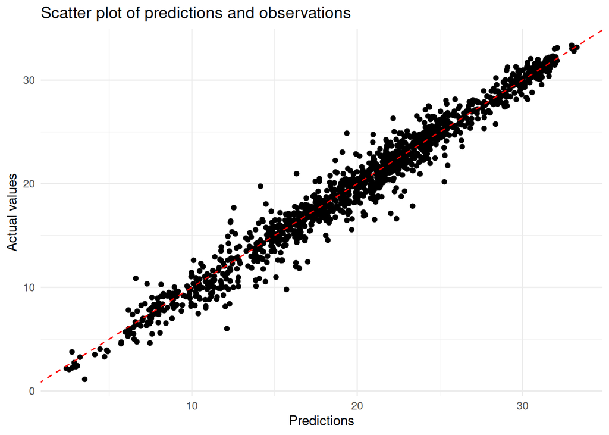

```r
predictions <- pred_test$.pred
actual_values <- pred_test$temperature

ggplot(data = data.frame(predictions, actual_values),
       aes(x=predictions, y=actual_values))+
  geom_point()+
  geom_abline(intercept=0, slope=1, linetype="dashed", color = "red")+
  labs(title = "Scatter plot of predictions and observations",
  x = "Predictions",
  y = "Actual values") +
  theme_minimal()
```

#Step 7: Deploy model

```r
#same as deterministic forecast
targets_future <- noaa_future_daily |>
  dplyr::mutate(temperature = NA,
         doy = yday(datetime)) |>
  filter(parameter == 1) |>
  select(-parameter)

#You will notice that the temperature is all NA because you don’t know what the temperature is of the site.

targets_future
```

```
## # A tibble: 238 × 9
##    datetime   site_id air_temperature northward_wind eastward_wind
##    <date>     <chr>             <dbl>          <dbl>         <dbl>
##  1 2025-12-27 LIRO              0.756         0.500          1.99
##  2 2025-12-28 LIRO             -1.66          2.61          -0.745
##  3 2025-12-29 LIRO            -14.8           5.07          -5.26
##  4 2025-12-30 LIRO            -12.8           3.23          -1.90
##  5 2025-12-31 LIRO             -8.76          3.59          -2.24
##  6 2026-01-01 LIRO            -12.9           1.24          -3.15
##  7 2026-01-02 LIRO            -13.4           0.237         -0.720
##  8 2026-01-03 LIRO             -9.80          0.0431         2.73
##  9 2026-01-04 LIRO             -4.33          1.08           0.948
## 10 2026-01-05 LIRO             -3.91         -1.27           1.37
## # ℹ 228 more rows
## # ℹ 4 more variables: surface_downwelling_shortwave_flux_in_air <dbl>,
## #   windspeed <dbl>, temperature <lgl>, doy <dbl>
```

```r
#As in “Step 5: Predict Test Data”, use the model fitting on the training data (fit) to predict the new data.
new_predictions <- predict(fit, new_data = targets_future)

#Probabilistic forecast
#residual for each ensemble prediction
residuals <- pred_test$.pred - pred_test$temperature
err <- mean(residuals, na.rm = TRUE)

#Create sigma distribution to use for process uncertainty later
sigma <- sd(residuals, na.rm = TRUE)

targets_future <- noaa_future_daily |>
  mutate(temperature = NA,
         doy = yday(datetime))

tidymodels_forecast <- data.frame()

for(i in unique(targets_future$parameter)){
  curr_ens <- targets_future |>
    filter(parameter == i) |>
    select(-parameter)

  new_predictions <- predict(fit, new_data = curr_ens)

  #add process uncertainty to each ensemble members
  new_predictions$.pred = new_predictions$.pred + rnorm(n = length(new_predictions$.pred), mean = 0, sd = sigma)
  curr_ens <- bind_cols(curr_ens, new_predictions) |>
    mutate(parameter = i)

  tidymodels_forecast <- bind_rows(tidymodels_forecast, curr_ens)
}
```

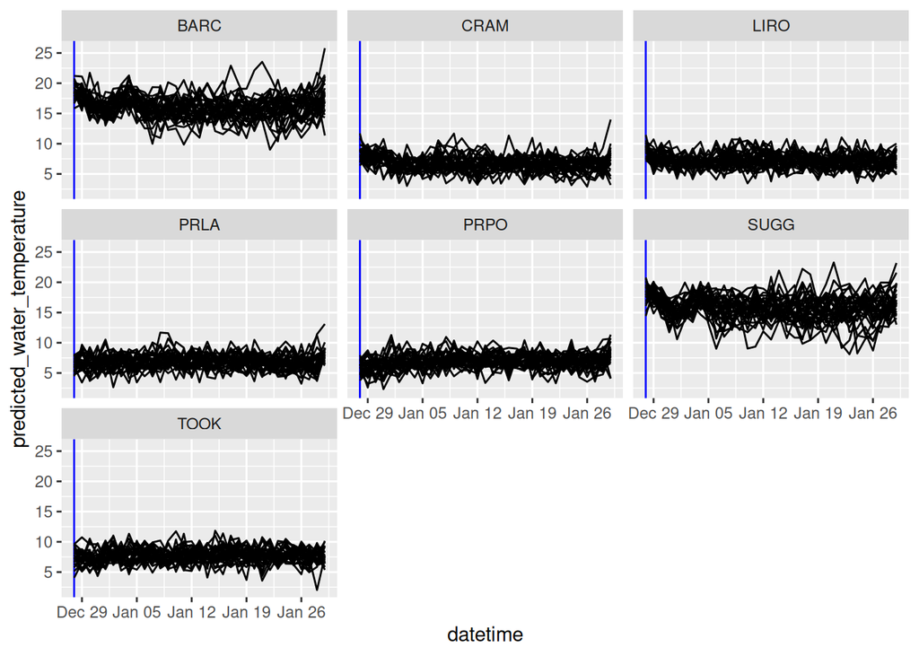

```r
tidymodels_forecasts_EFI <- tidymodels_forecast %>%
  rename(predicted_water_temperature = .pred) %>%
  mutate(variable = "temperature") |>
  # For the EFI challenge we only want the forecast for future
  filter(datetime > Sys.Date()) %>%
  group_by(site_id, variable) %>%
  mutate(reference_datetime = min(datetime) - lubridate::days(1),
         family = "ensemble",
         model_id = "tidymodels_RF") %>%
  select(model_id, datetime, reference_datetime, site_id, family, parameter, variable, predicted_water_temperature)

tidymodels_forecasts_EFI |>
  filter(variable == "temperature") |>
  ggplot(aes(x = datetime, y = predicted_water_temperature, group = parameter)) +
  geom_vline(aes(xintercept = Sys.Date() + lubridate::days(1)), color = "blue")+
  geom_line() +
  facet_wrap(~site_id)
```

Remember to change the model_id when you make changes to the model structure!

## Convert to EFI standard for submission

For an ensemble forecast the documentation specifies the following columns:

- `datetime`: forecast timestamp for each time step
- `reference_datetime`: The start of the forecast; this should be 0 times steps in the future. This should only be one value of reference_datetime in the file
- `site_id`: NEON code for site
- `family`: name of probability distribution that is described by the parameter values in the parameter column; only `normal` or `ensemble` are currently allowed.
- `parameter`: integer value for forecast replicate (from the `.rep` in fable output);
- `variable`: standardized variable name from the theme
- `prediction`: forecasted value (from the `.sim` column in fable output)
- `model_id`: model name (no spaces). Any model_id that includes ‘example’ will not be included in analysis. It will still be evaluated against observations but will be deleted. This is good for testing and trying out new modelling ideas.

We need to make sure the dataframe is in the correct format and then we can submit this to the challenge as well! This is an ensemble forecast (specified in the `family` column).

Remember to change the model_id when you make changes to the model structure!

```r
my_model_id <- 'bee_bake_RFModel_2024'
```

```r
# Make forecast fit the EFI standards
tidymodels_forecasts_EFI <- tidymodels_forecast %>%
  filter(datetime > forecast_date) %>%
  mutate(model_id = my_model_id,
         reference_datetime = forecast_date,
         family = 'ensemble',
         variable = 'temperature',
         prediction = .pred,
         parameter = as.character(parameter)) %>%
  select(datetime, reference_datetime, site_id, family, parameter, variable, prediction, model_id)
```

```r
# Write the forecast to file
theme <- 'aquatics'
date <- tidymodels_forecasts_EFI$reference_datetime[1]
forecast_name_1 <- paste0(tidymodels_forecasts_EFI$model_id[1], ".csv")
forecast_file_1 <- paste(theme, date, forecast_name_1, sep = '-')
forecast_file_1
```

```
## [1] "aquatics-2025-12-27-bee_bake_RFModel_2024.csv"
```

```r
if (!dir.exists('Forecasts')) {
  dir.create('Forecasts')
}

write_csv(tidymodels_forecasts_EFI, file.path('Forecasts',forecast_file_1))
```

Check that forecast format is valid

```r
neon4cast::forecast_output_validator(file.path('Forecasts',forecast_file_1))
```

```
## Forecasts/aquatics-2025-12-27-bee_bake_RFModel_2024.csv
```

```
## ✔ file has model_id column
## ✔ only one unique value in the model_id column
## ✔ forecasted variables found correct variable + prediction column
## ✔ temperature is a valid variable name
## ✔ file has correct family and parameter columns
## ✔ only one unique value in the family column
## ✔ file has site_id column
## ✔ file has datetime column
## ✔ file has correct datetime column
```

```
## ✔ file has reference_datetime column
## Forecast format is valid
```

```
## [1] TRUE
```

Change eval = TRUE if you want to submit

```r
neon4cast::submit(forecast_file = file.path('Forecasts', forecast_file_1), ask = FALSE) # if ask = T (default), it will produce a pop-up box asking if you want to submit
```

```
## validating that file matches required standard
```

```
## Forecasts/aquatics-2025-12-27-bee_bake_RFModel_2024.csv
```

```
## ✔ file has model_id column
## ✔ only one unique value in the model_id column
## ✔ forecasted variables found correct variable + prediction column
## ✔ temperature is a valid variable name
## ✔ file has correct family and parameter columns
## ✔ only one unique value in the family column
## ✔ file has site_id column
## ✔ file has datetime column
## ✔ file has correct datetime column
```

```
## ✔ file has reference_datetime column
## Forecast format is valid
##
## Thank you for submitting!
```

#Plot the forecast

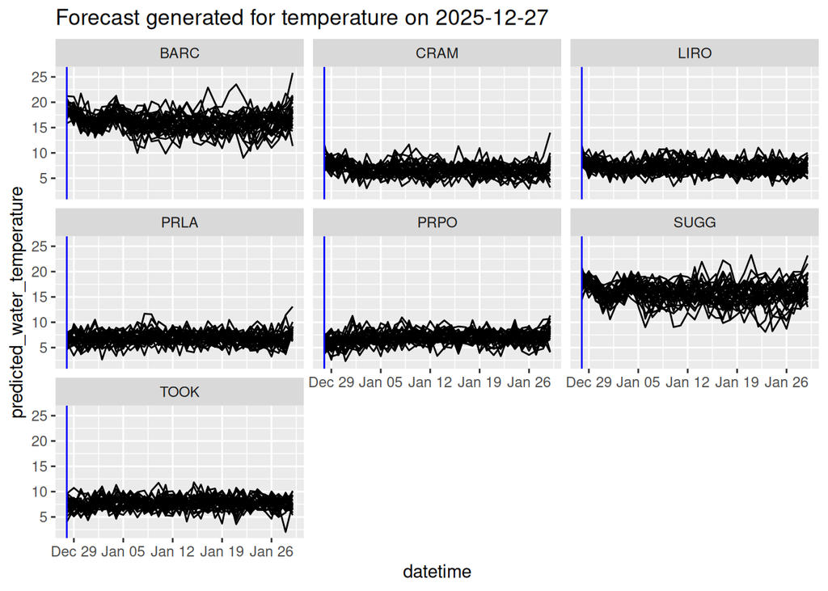

```r
tidymodels_forecasts_EFI |>
  ggplot(aes(x=datetime, y=prediction, group = parameter)) +
  geom_line() +
  ylab("predicted_water_temperature")+
  facet_wrap(~site_id) +
  geom_vline(aes(xintercept = Sys.Date() + lubridate::days(1)), color = "blue")+
  labs(title = paste0('Forecast generated for ', tidymodels_forecasts_EFI$variable[1], ' on ', tidymodels_forecasts_EFI$reference_datetime[1]))
```

#The end!